# Main

Chengliang Tang, Yujie Wang, Diane Lu, Tian Zheng

In your final repo, there should be an R markdown file that organizes **all computational steps** for evaluating your proposed Facial Expression Recognition framework.

This file is currently a template for running evaluation experiments. You should update it according to your codes but following precisely the same structure.

```r
if(!require("EBImage")){
  install.packages("BiocManager")
  BiocManager::install("EBImage")
}
if(!require("R.matlab")){
  install.packages("R.matlab")
}
if(!require("readxl")){
  install.packages("readxl")
}

if(!require("dplyr")){
  install.packages("dplyr")
}
if(!require("readxl")){
  install.packages("readxl")
}

if(!require("ggplot2")){
  install.packages("ggplot2")
}

if(!require("caret")){
  install.packages("caret")
}

if(!require("glmnet")){
  install.packages("glmnet")
}

if(!require("WeightedROC")){
  install.packages("WeightedROC")
}

if(!require("gbm")){
  install.packages("gbm")
}

if(!require("DMwR")){
  install.packages("DMwR")
}

if(!require("formatR")){
  install.packages("formatR")
}

if(!require("pROC")){
  install.packages("pROC")
}

library(R.matlab)
library(readxl)
library(dplyr)
library(EBImage)
library(ggplot2)
library(caret)
library(glmnet)
library(WeightedROC)
library(gbm)
library(grid)
library(gridExtra)
library(e1071)
library(pROC)
library(DMwR)
library(formatR)
```

### Step 0 set work directories

```r
set.seed(2020)
# setwd("~/Project3-FacialEmotionRecognition/doc")
# here replace it with your own path or manually set it in RStudio to where this rmd file is located.
# use relative path for reproducibility
```

Provide directories for training images. Training images and Training fiducial points will be in different subfolders.

```r
train_dir <- "../data/train_set/" # This will be modified for different data sets.
train_image_dir <- paste(train_dir, "images/", sep="")
train_pt_dir <- paste(train_dir,  "points/", sep="")
train_label_path <- paste(train_dir, "label.csv", sep="")
```

### Step 1: set up controls for evaluation experiments.

In this chunk, we have a set of controls for the evaluation experiments.

- (T/F) cross-validation on the training set
- (T/F) reweighting the samples for training set
- (number) K, the number of CV folds
- (T/F) process features for training set
- (T/F) run evaluation on an independent test set
- (T/F) process features for test set

```r
K <- 5  # number of CV folds
#runpca <- FALSE

run.fudicial.list <- TRUE
run.feature.train <- TRUE
run.feature.test <- TRUE


run.cv.svm <-  TRUE # run cross-validation on the training set
run.train.svm <- TRUE # process features for training set
run.test.svm <- TRUE # run evaluation on an independent test set
run.cv.pca <- TRUE # process features for test set
```

### Step 2: import data and train-test split

```r
#train-test split
info <- read.csv(train_label_path)
n <- nrow(info)
n_train <- round(n*(4/5), 0)
train_idx <- sample(info$Index, n_train, replace = F)
test_idx <- setdiff(info$Index, train_idx)
```

Fiducial points are stored in matlab format. In this step, we read them and store them in a list.

```r
n_files <- length(list.files(train_image_dir))

if (TRUE){
  readMat.matrix <- function(index){
       return(round(readMat(paste0(train_pt_dir, sprintf("%04d", index), ".mat"))[[1]],0))
  }

  fiducial_pt_list <- lapply(1:n_files, readMat.matrix)
  save(fiducial_pt_list, file="../output/fiducial_pt_list.RData")

  # otherwise load the data stored for convenience
} else {
  load(file="../output/fiducial_pt_list.RData")
}
```

### Step 3: construct features and responses

```r
source("../lib/feature.R")
tm_feature_train <- NA
if(TRUE){
  tm_feature_train <- system.time(dat_train <- feature(fiducial_pt_list, train_idx))
  save(dat_train, file="../output/feature_train.RData")
}else{
  load(file="../output/feature_train.RData")
}

tm_feature_test <- NA
if(TRUE){
  tm_feature_test <- system.time(dat_test <- feature(fiducial_pt_list, test_idx))
  save(dat_test, file="../output/feature_test.RData")
}else{
  load(file="../output/feature_test.RData")
}
```

### Step 4: SVM

Call the train model and test model from library.

`train.R` and `test.R` should be wrappers for all your model training steps and your classification/prediction steps.

#### Model selection with cross-validation

- Do model selection by choosing among different values of training model parameters.

```r
source("../lib/cross_validation_svm.R")
```

```r
cost = c(0.02,0.04,0.06,0.08,0.1)

feature_train = as.matrix(dat_train[,-6007])
label_train = as.integer(dat_train$label)

if(FALSE){
  res_cv_svm <- matrix(0, nrow = length(cost), ncol = 4)
  for(i in 1:length(cost)){
    cat("Cost = ", hyper_grid_svm$svm.cost[i], "\n")

    res_cv_svm[i,] <- cv.function(features = feature_train, labels = label_train, K=5, cost[i])
    save(res_cv_svm, file="../output/res_cv_svm.RData")
  }

}else{
  load("../output/res_cv_svm.RData")
}
```

Visualize cross-validation results.

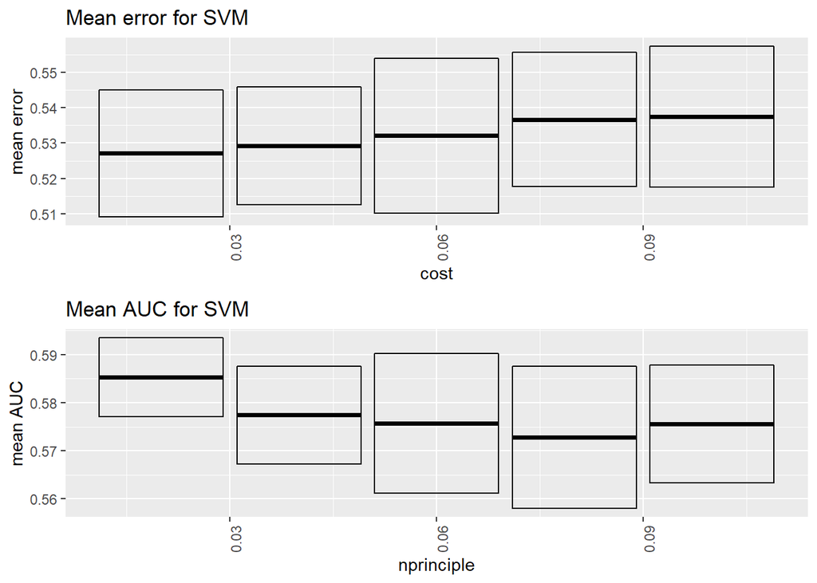

```r
res_cv_svm <- as.data.frame(res_cv_svm)
colnames(res_cv_svm) <- c("mean_error", "sd_error","mean_AUC","sd_AUC")
res_cv_svm$k = as.factor(cost)

p1 <- res_cv_svm %>%
  ggplot(aes(x = cost, y = mean_error,
              ymin = mean_error - sd_error, ymax = mean_error + sd_error)) +
  geom_crossbar() +
  theme(axis.text.x = element_text(angle = 90, hjust = 1))+
  labs(title="Mean error for SVM",y="mean error", x="cost")
p2 <- res_cv_svm %>%
  ggplot(aes(x = cost, y = mean_AUC,
              ymin = mean_AUC - sd_AUC, ymax = mean_AUC + sd_AUC)) +
  geom_crossbar() +
  theme(axis.text.x = element_text(angle = 90, hjust = 1))+
  labs(title="Mean AUC for SVM", y="mean AUC", x="nprinciple")
grid.arrange(p1, p2, nrow=2)
```

- Choose the “best” parameter value

```r
par_best <- cost[which.min(res_cv_svm[,1])] # lmbd[which.max(res_cv$mean_AUC)]
```

- Train the model with the entire training set using the selected model (model parameter) via cross-validation.

```r
# training weights


if(TRUE){

  tm_train_svm <- system.time(fit_train_svm <- svm(label ~., data = dat_train, kernel = "linear", cost = par_best))

  save(fit_train_svm, file="../output/fit_train_svm.RData")

}else{
  load(file="../output/fit_train_svm.RData")

}
```

### Step 5: Run test on test images

```r
if(TRUE){
  load(file="../output/fit_train_svm.RData")

  tm_test_svm <- system.time(pred_svm <- predict(fit_train_svm, dat_test))
}
```

- evaluation

```r
accu_svm <- mean(dat_test$label == pred_svm)
real_label = dat_test$label %>% as.character() %>% as.numeric()
pred_value_svm  = pred_svm %>% as.character() %>% as.numeric()



cat("The accuracy is: ", accu_svm*100, "%.\n")
```

```
## The accuracy is:  82.16667 %.
```

```r
cat("The AUC is", roc(pred_value_svm, real_label)$auc, ".\n")
```

```
## The AUC is 0.7438564 .
```

### Summarize Running Time

Prediction performance matters, so does the running times for constructing features and for training the model, especially when the computation resource is limited.

```r
cat("Time for training model=", tm_train_svm[1], "s \n")
```

```
## Time for training model= 60.91 s
```

```r
cat("Time for testing model=", tm_test_svm[1], "s \n")
```

```
## Time for testing model= 4.58 s
```

###Reference - Du, S., Tao, Y., & Martinez, A. M. (2014). Compound facial expressions of emotion. Proceedings of the National Academy of Sciences, 111(15), E1454-E1462.